# Cleaning WVS Data

## Varaible Reduction: PCA on Question’s Precentage Dataframe

In order to reduce the number of variables going to into the PCA, we could reduce the dummy varaibles into dummy dimensions by conducting a PCA on the precentage dataframes. This will create one dimension for each questions representing all the dummy varaiables.

```r
PCA2a_Scores <- c()

for (DF in Cat_Questions_CountDF){
  PCA_DF <- prcomp(DF)
  PCA2a_Scores_DF <- PCA_DF $x[,1]
  PCA2a_Scores <- cbind(PCA2a_Scores, PCA2a_Scores_DF)
}

for (DF in Ordinal_Question_CountDF){
  PCA_DF <- prcomp(DF)
  PCA2a_Scores_DF <- as.data.frame(PCA_DF $x[,1])
  PCA2a_Scores <- cbind(PCA2a_Scores, PCA2a_Scores_DF)
}

PCA2a_colnames <- c('V4','V5','V6','V7','V8','V9','V10','V11','V12','V13','V14','V15','V16',
                   'V17','V18','V19','V20','V21',
                   'V22','V25','V26','V27','V28','V29','V30','V31','V32','V33','V34','V35',
                   'V37','V42','V39','V38','V36',
                   'V40','V41','V43','V44','V24','V70','V71','V72','V73','V75','V76','V77',
                   'V78','V79','V74','V165',
                   'V166','V167','V168','V169','V81','V82','V83','V45','V46',
                   'V102','V49','V54','V51','V52','V50',
                   'V48','V47','V53','V60','V61','V62','V63','V64','V65','V66','V67','V68',
                   'V69','V80','V84','V85',
                   'V86','V87','V88','V89','V108','V109','V110','V111','V112','V113','V114',
                   'V115','V116','V117',
                   'V118','V119','V120','V121','V122','V123','V124','V126','V127','V128','V129','V130','V142','V217',
                   'V218','V219','V220','V221','V222','V223','V224','V225','V226','V227','V143','V145','V146','V147',
                   'V148','V149','V150','V151','V153','V154','V155','V156','V211','V103','V104',"V105",'V106','V107','V212',
                   'V213','V214','V216','V243','V244','V245','V246','V170','V171','V172','V173','V174','V175','V176',
                   'V177','V178','V179','V180','V181','V182','V183','V184','V185','V186','V187','V188','V189','V190',
                   'V191',
                   'V23_Category','V56_Category','V55_Category','V157_Category','V158_Category','V159_Category',
                   'V160_Category','V164_Category','V59_Category','V95_Category','V96_Category','V97_Category',
                   'V98_Category','V99_Category','V100_Category','V101_Category','V131_Category','V132_Category',
                   'V134_Category','V135_Category','V136_Category','V137_Category','V138_Category',
                   'V141_Category','V192_Category','V194_Category',
                   'V197_Category','V198_Category','V200_Category','V209_Category',
                   'V210_Category','V199_Category','V201_Category','V202_Category','V203_Category',
                   'V204_Category','V205_Category','V207_Category', 'V206_Category','V208_Category',
                   'V195_Category',"V196_Cateogry",
                   'V161_Categorized', 'V162_Categorized', 'V163_Categorized')

colnames(PCA2a_Scores) <- PCA2a_colnames

PCA_2 <- prcomp(PCA2a_Scores)
summary(PCA_2)
```

```
## Importance of components:
##                              PC1       PC2       PC3       PC4       PC5
## Standard deviation     6050.8330 1.790e+03 1.391e+03 1239.9458 1.108e+03
## Proportion of Variance    0.7193 6.291e-02 3.803e-02    0.0302 2.411e-02
## Cumulative Proportion     0.7193 7.822e-01 8.202e-01    0.8504 8.745e-01
##                             PC6       PC7       PC8       PC9      PC10
## Standard deviation     885.3253 879.02251 786.80171 700.38982 623.79296
## Proportion of Variance   0.0154   0.01518   0.01216   0.00964   0.00764
## Cumulative Proportion    0.8899   0.90511   0.91727   0.92691   0.93455
##                             PC11      PC12      PC13      PC14      PC15
## Standard deviation     572.08319 567.47175 541.08000 486.42439 454.76228
## Proportion of Variance   0.00643   0.00633   0.00575   0.00465   0.00406
## Cumulative Proportion    0.94098   0.94731   0.95306   0.95771   0.96177
##                             PC16      PC17      PC18     PC19      PC20
## Standard deviation     433.39613 425.82033 387.10087 349.8215 325.69538
## Proportion of Variance   0.00369   0.00356   0.00294   0.0024   0.00208
## Cumulative Proportion    0.96546   0.96902   0.97197   0.9744   0.97645
##                             PC21      PC22      PC23     PC24     PC25
## Standard deviation     315.84536 295.46726 283.35041 276.3166 256.9409
## Proportion of Variance   0.00196   0.00172   0.00158   0.0015   0.0013
## Cumulative Proportion    0.97841   0.98013   0.98171   0.9832   0.9845
##                             PC26      PC27      PC28      PC29      PC30
## Standard deviation     251.48256 246.56752 234.82868 226.39963 216.03640
## Proportion of Variance   0.00124   0.00119   0.00108   0.00101   0.00092
## Cumulative Proportion    0.98575   0.98694   0.98802   0.98903   0.98995
##                             PC31      PC32      PC33      PC34      PC35
## Standard deviation     200.91436 193.72124 186.51755 180.61817 178.13901
## Proportion of Variance   0.00079   0.00074   0.00068   0.00064   0.00062
## Cumulative Proportion    0.99074   0.99148   0.99216   0.99280   0.99342
##                             PC36      PC37      PC38      PC39      PC40
## Standard deviation     172.37124 168.12867 161.40524 156.18263 152.38832
## Proportion of Variance   0.00058   0.00056   0.00051   0.00048   0.00046
## Cumulative Proportion    0.99401   0.99456   0.99508   0.99555   0.99601
##                             PC41      PC42      PC43      PC44      PC45
## Standard deviation     144.69954 138.67941 131.55533 127.81263 120.75214
## Proportion of Variance   0.00041   0.00038   0.00034   0.00032   0.00029
## Cumulative Proportion    0.99642   0.99680   0.99714   0.99746   0.99775
##                             PC46      PC47      PC48      PC49    PC50
## Standard deviation     119.54520 113.16013 109.90752 103.79167 99.8391
## Proportion of Variance   0.00028   0.00025   0.00024   0.00021  0.0002
## Cumulative Proportion    0.99803   0.99828   0.99852   0.99873  0.9989
##                            PC51     PC52     PC53     PC54     PC55
## Standard deviation     96.31158 88.89924 86.32147 83.47288 75.24138
## Proportion of Variance  0.00018  0.00016  0.00015  0.00014  0.00011
## Cumulative Proportion   0.99911  0.99926  0.99941  0.99955  0.99966
##                            PC56     PC57     PC58     PC59      PC60
## Standard deviation     74.02322 68.36243 63.54333 57.34864 2.687e-12
## Proportion of Variance  0.00011  0.00009  0.00008  0.00006 0.000e+00
## Cumulative Proportion   0.99976  0.99986  0.99994  1.00000 1.000e+00
```

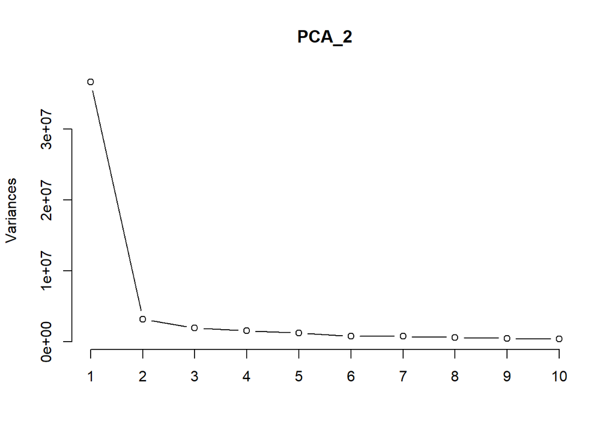

```r
plot(PCA_2, type = "l")
```

```r
#Loadings have variables as rows
PCA_Loadings2 <- round(PCA_2$rotation [,c(1:5)], 3)
head(PCA_Loadings2)
```

```
##       PC1    PC2    PC3    PC4    PC5
## V4  0.104  0.032  0.006 -0.023  0.069
## V5 -0.072 -0.043 -0.023 -0.007 -0.034
## V6  0.064  0.052 -0.002  0.010  0.022
## V7  0.058  0.038  0.006  0.009  0.019
## V8  0.080 -0.061  0.013 -0.035  0.049
## V9 -0.060  0.242 -0.006  0.040 -0.140
```

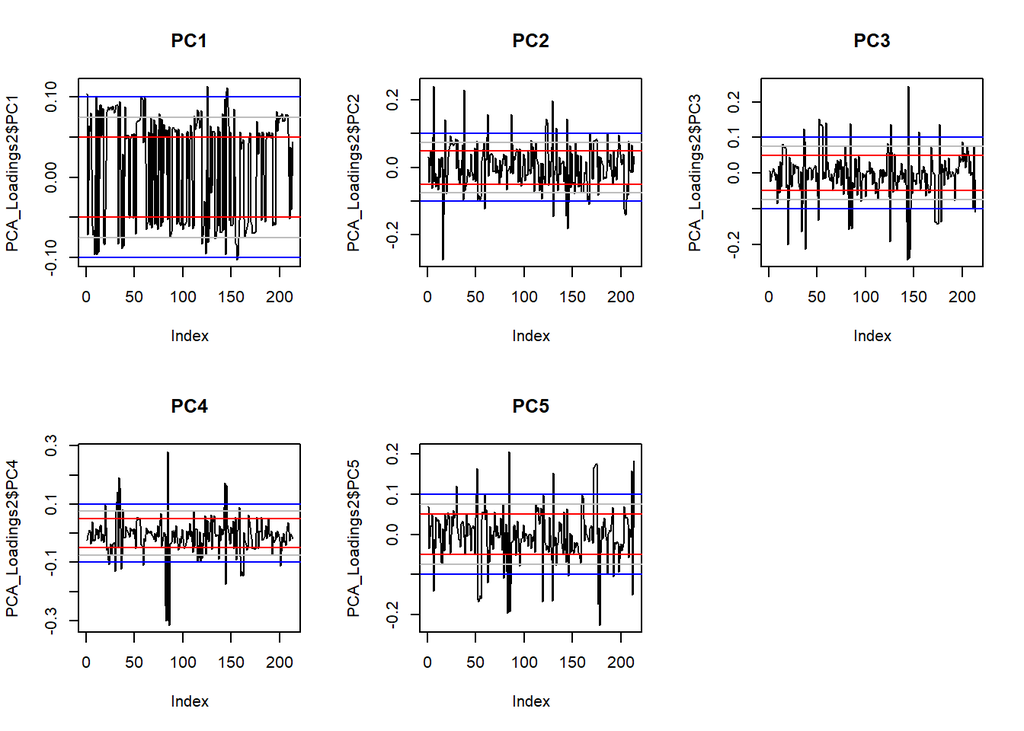

```r
PCA_Loadings2 <- as.data.frame(PCA_Loadings2)


#Plots of Components
#pdf("Loading distribution2.pdf", paper = "USr")
par(mfrow=c(2,3))

plot(PCA_Loadings2$PC1, type = "l", main = "PC1")
abline(h=0.05, col="red")
abline(h=-0.05, col="red")
abline(h=0.075, col="grey")
abline(h=-0.075, col="grey")
abline(h=0.1, col="blue")
abline(h=-0.1, col="blue")

plot(PCA_Loadings2$PC2, type = "l", main = "PC2")
abline(h=0.05, col="red")
abline(h=-0.05, col="red")
abline(h=0.075, col="grey")
abline(h=-0.075, col="grey")
abline(h=0.1, col="blue")
abline(h=-0.1, col="blue")

plot(PCA_Loadings2$PC3, type = "l", main = "PC3")
abline(h=0.05, col="red")
abline(h=-0.05, col="red")
abline(h=0.075, col="grey")
abline(h=-0.075, col="grey")
abline(h=0.1, col="blue")
abline(h=-0.1, col="blue")

plot(PCA_Loadings2$PC4, type = "l", main = "PC4")
abline(h=0.05, col="red")
abline(h=-0.05, col="red")
abline(h=0.075, col="grey")
abline(h=-0.075, col="grey")
abline(h=0.1, col="blue")
abline(h=-0.1, col="blue")

plot(PCA_Loadings2$PC5, type = "l", main = "PC5")
abline(h=0.05, col="red")
abline(h=-0.05, col="red")
abline(h=0.075, col="grey")
abline(h=-0.075, col="grey")
abline(h=0.1, col="blue")
abline(h=-0.1, col="blue")

#dev.off()
```

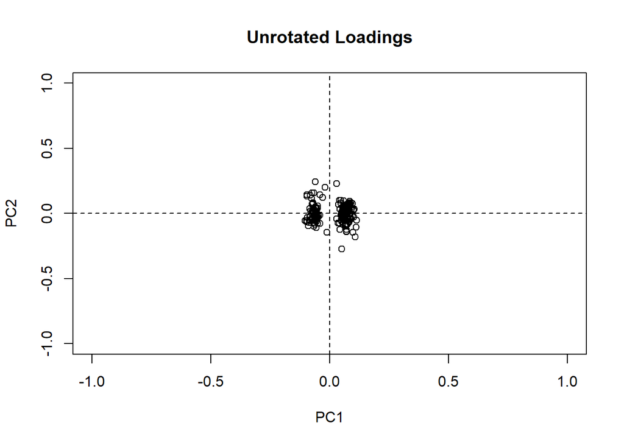

```r
PCA_2.Varimax <-varimax(PCA_2$rotation)

plot(PCA_2$rotation [,c(1:2)], xlim = c(-1, 1), ylim = c(-1, 1), main = "Unrotated Loadings")
abline(v = 0, h = 0, lty = 2)
```

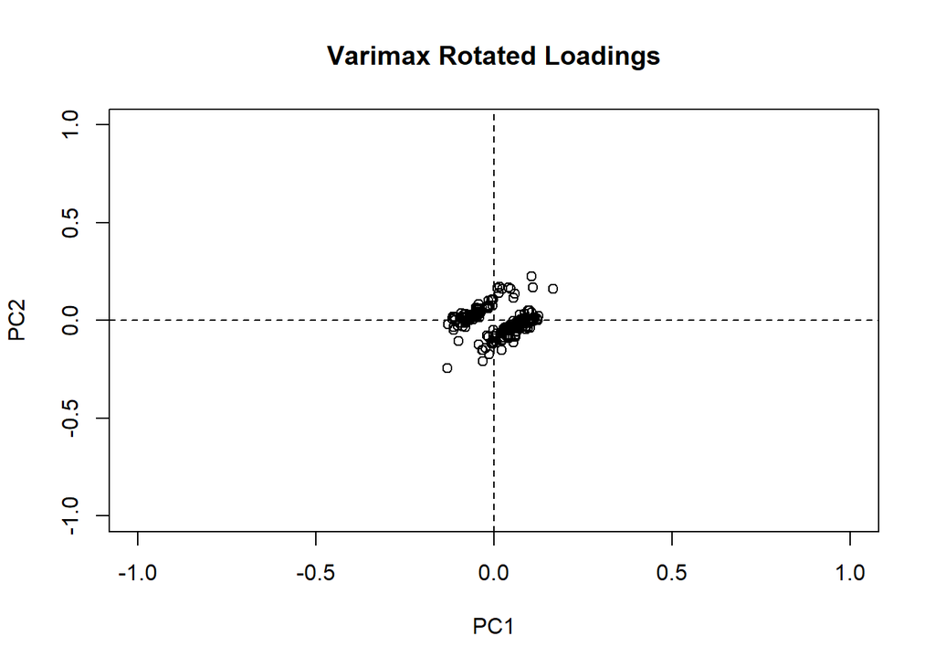

```r
plot(varimax(PCA_2$rotation [,c(1:2)])$loadings, xlim = c(-1, 1), ylim = c(-1, 1), main = "Varimax Rotated Loadings")
abline(v = 0, h = 0, lty = 2)
```

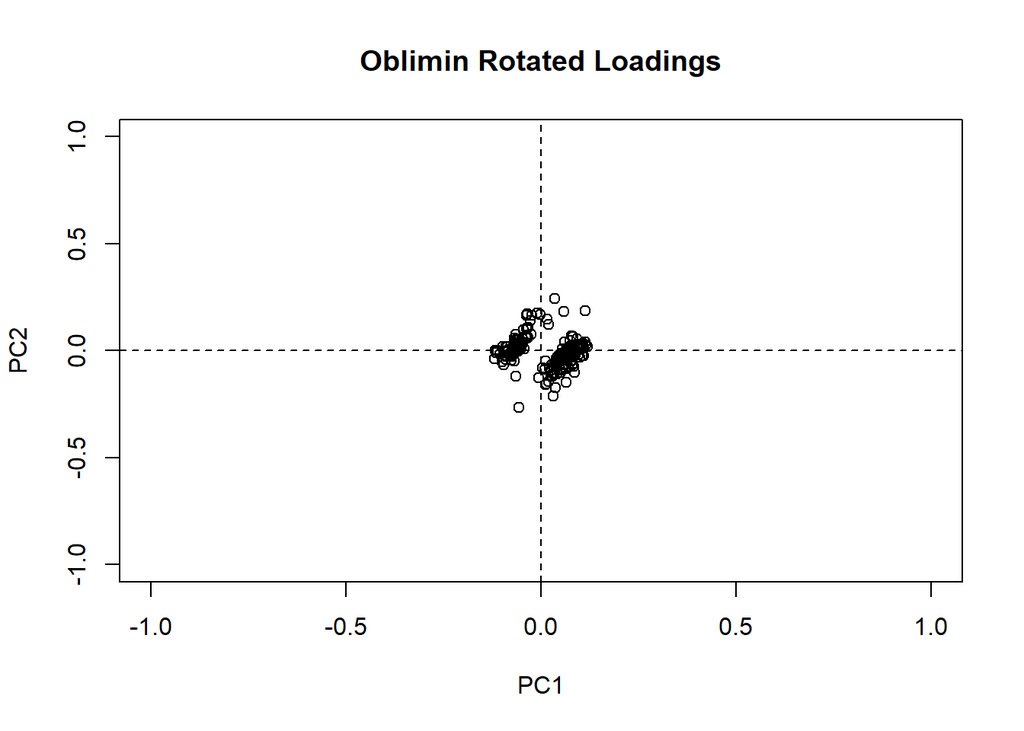

```r
plot(oblimin(PCA_2$rotation [,c(1:2)])$loadings, xlim = c(-1, 1), ylim = c(-1, 1), main = "Oblimin Rotated Loadings")
abline(v = 0, h = 0, lty = 2)
```

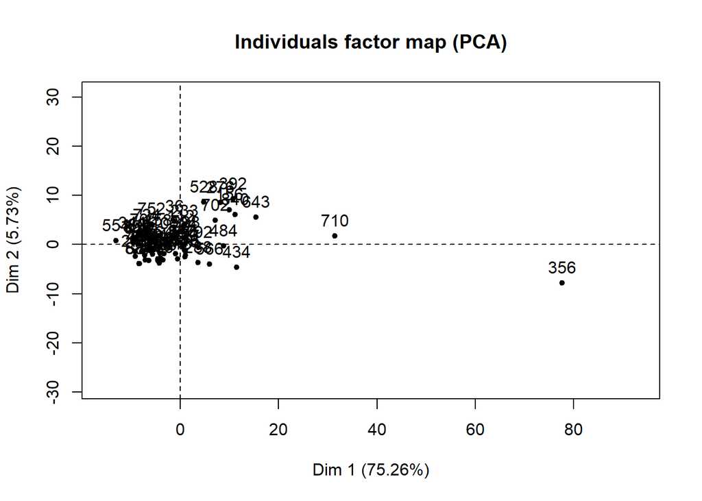

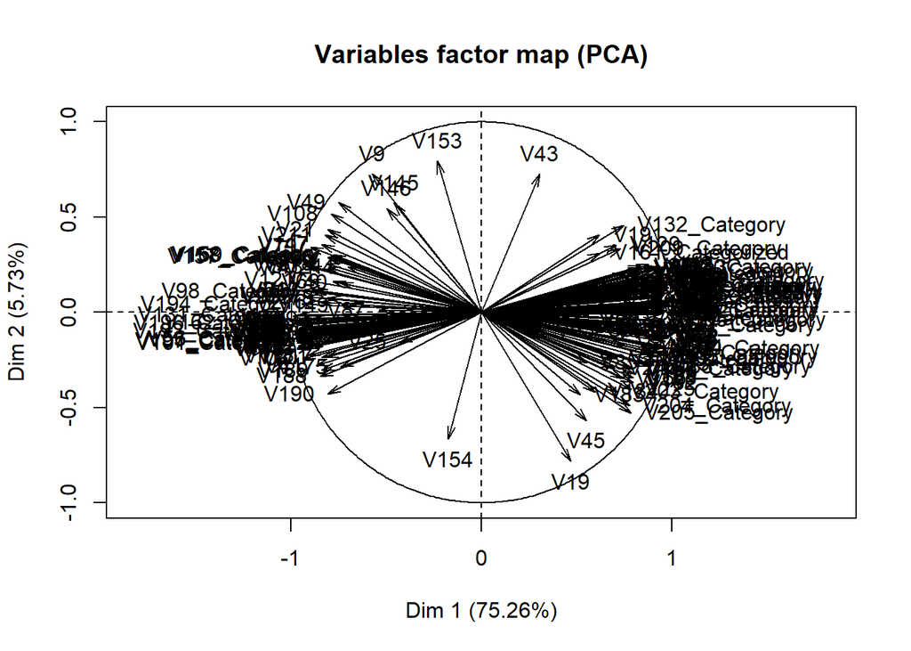

```
## **Results for the Principal Component Analysis (PCA)**
## The analysis was performed on 60 individuals, described by 213 variables
## *The results are available in the following objects:
##
##    name               description
## 1  "$eig"             "eigenvalues"
## 2  "$var"             "results for the variables"
## 3  "$var$coord"       "coord. for the variables"
## 4  "$var$cor"         "correlations variables - dimensions"
## 5  "$var$cos2"        "cos2 for the variables"
## 6  "$var$contrib"     "contributions of the variables"
## 7  "$ind"             "results for the individuals"
## 8  "$ind$coord"       "coord. for the individuals"
## 9  "$ind$cos2"        "cos2 for the individuals"
## 10 "$ind$contrib"     "contributions of the individuals"
## 11 "$call"            "summary statistics"
## 12 "$call$centre"     "mean of the variables"
## 13 "$call$ecart.type" "standard error of the variables"
## 14 "$call$row.w"      "weights for the individuals"
## 15 "$call$col.w"      "weights for the variables"
```

```r
PCA(PCA2a_Scores)
```

```r
PCA_Loadings2[abs(PCA_Loadings2) < 0.1] = NA
PCA_Loadings_Cleaned2 <- PCA_Loadings2[rowSums(is.na(PCA_Loadings2))!= 5, ]
head(PCA_Loadings_Cleaned2)
```

```
##       PC1    PC2  PC3 PC4   PC5
## V4  0.104     NA   NA  NA    NA
## V9     NA  0.242   NA  NA -0.14
## V13 0.101     NA   NA  NA    NA
## V19    NA -0.274   NA  NA    NA
## V21    NA  0.141   NA  NA    NA
## V25    NA     NA -0.2  NA    NA
```

```r
PCA_Scores2 <- PCA_2$x[,c(1:5)]
head(PCA_Scores2)
```

```
##           PC1        PC2        PC3       PC4        PC5
## 12 -2762.2927 -1595.3954   81.64017 -264.1887   198.1973
## 31 -3308.9054  -625.3844  199.03206 -693.5085  -591.1486
## 32 -3989.5381   203.7711 -285.26932  482.5313 -1315.9535
## 36  -755.7798  2231.6765  -68.35972  836.5992  -926.6749
## 48 -4782.2816  -886.9466 1472.29427 2429.1012   300.1651
## 51 -2375.7080  -916.1771  153.80457 -804.4471  -265.3537
```

```r
#Need to manually remove countries from sensitivity analysis -
#414 - Kuwait
#634 - Qatar
#48 - Bahrain
#818 - Egypt
Remove_Countries <- c(414,634,48,818)
PCA_Scores2 <- PCA_Scores2[ !(rownames(PCA_Scores2) %in% Remove_Countries), ]

Named_PCA_Analysis_Data2 <- merge(Country_Names, PCA_Scores2, by.y= 0, by.x ="Country.Code", all.y=T)

Renewable_Scores2 <- merge(Renewable_merge, Named_PCA_Analysis_Data2,
                                   by.x="Country.Name", by.y="Country.Title")

Renewable_Scores2 <- Renewable_Scores2[,c(1:7, 12:17)]
Renewable_Scores2 <- na.omit(Renewable_Scores2)
```

### Varaible Reduction: PCA on Question’s Precentage Dataframe - Final Data for Regression

This is the dataframe we will use to explore the relationships between renewable electricity production and cultural values.

```r
Final_Data <- Renewable_Scores2
```

### Varaible Reduction: PCA on Question’s Precentage Dataframe - Linear Regression

```r
fullregression <- lm(log(Final_Data$RE_Generation +1) ~ Final_Data$PC1 + Final_Data$PC2 )
summary(fullregression)
```

```
##
## Call:
## lm(formula = log(Final_Data$RE_Generation + 1) ~ Final_Data$PC1 +
##     Final_Data$PC2)
##
## Residuals:
##     Min      1Q  Median      3Q     Max
## -1.7639 -0.7562 -0.2446  0.9197  2.0531
##
## Coefficients:
##                 Estimate Std. Error t value Pr(>|t|)
## (Intercept)    1.128e+00  1.388e-01   8.125 1.07e-10 ***
## Final_Data$PC1 1.049e-06  2.215e-05   0.047  0.96240
## Final_Data$PC2 2.371e-04  7.501e-05   3.161  0.00267 **
## ---
## Signif. codes:  0 '***' 0.001 '**' 0.01 '*' 0.05 '.' 0.1 ' ' 1
##
## Residual standard error: 1.007 on 50 degrees of freedom
## Multiple R-squared:  0.1666, Adjusted R-squared:  0.1333
## F-statistic: 4.998 on 2 and 50 DF,  p-value: 0.0105
```

### Varaible Reduction: PCA on Question’s Precentage Dataframe - Control for GDP

```r
GDP_rawdata <- read.csv("World_Bank_GDP_Data.csv")
GDP_Years <- GDP_rawdata[4,]

#remove first 4 rows to bring column headers to top
GDP_data <- GDP_rawdata[c(5:286),]
colnames(GDP_data) <- GDP_Years

#remove all columns except for country names, and 2015 GDP
GDP_data2015 <-GDP_data[,c(1,60)]
colnames(GDP_data2015)<- c("Country.Title", "2015 GDP")

GDP_data_named<-merge(GDP_data2015, Country_Names, by.x= "Country.Title", by.y = "Country.Title")

GDP_Control <- merge(GDP_data_named, Final_Data, by.x = "Country.Title", by.y= "Country.Name")

Control <- GDP_Control$`2015 GDP`/10^9 #down to 53 countries
```

```r
fullregression <- lm(log(Final_Data$RE_Generation +1) ~ Final_Data$PC1 + Final_Data$PC2 +
                       Control)
summary(fullregression)
```

```
##
## Call:
## lm(formula = log(Final_Data$RE_Generation + 1) ~ Final_Data$PC1 +
##     Final_Data$PC2 + Control)
##
## Residuals:
##     Min      1Q  Median      3Q     Max
## -1.7311 -0.8205 -0.1107  0.9830  2.0177
##
## Coefficients:
##                  Estimate Std. Error t value Pr(>|t|)
## (Intercept)     1.147e+00  1.523e-01   7.530 1.29e-09 ***
## Final_Data$PC1 -1.290e-06  2.354e-05  -0.055   0.9565
## Final_Data$PC2  2.155e-04  8.781e-05   2.454   0.0179 *
## Control         2.042e-05  5.746e-05   0.355   0.7239
## ---
## Signif. codes:  0 '***' 0.001 '**' 0.01 '*' 0.05 '.' 0.1 ' ' 1
##
## Residual standard error: 1.017 on 47 degrees of freedom
##   (2 observations deleted due to missingness)
## Multiple R-squared:  0.1633, Adjusted R-squared:  0.1099
## F-statistic: 3.059 on 3 and 47 DF,  p-value: 0.03725
```

### Varaible Reduction: PCA on Question’s Precentage Dataframe - Other Controls

```r
Renewable_Resources <- read.csv("Renewable_Resources.csv")

Renewable_Resources<- merge(Renewable_Resources, Final_Data, by.x = "Country.Code", by.y = "Country.Code")

Renewable_Gen<- Renewable_Resources$RE_Generation.x
PC1 <- Renewable_Resources$PC1
PC2 <- Renewable_Resources$PC2
Wind <- Renewable_Resources$Wind
Solar <- as.numeric(Renewable_Resources$Solar)
Policy <- Renewable_Resources$Policy.Target
```

```r
fullregression_resources <- lm(log(Renewable_Gen+1) ~ PC1 + PC2 +
                                 Wind + Solar + Policy)
summary(fullregression_resources)
```

```
##
## Call:
## lm(formula = log(Renewable_Gen + 1) ~ PC1 + PC2 + Wind + Solar +
##     Policy)
##
## Residuals:
##     Min      1Q  Median      3Q     Max
## -1.4659 -0.6599 -0.1461  0.6069  1.8476
##
## Coefficients:
##               Estimate Std. Error t value Pr(>|t|)
## (Intercept)  1.244e+00  2.271e-01   5.479 3.19e-06 ***
## PC1          3.880e-06  2.037e-05   0.190  0.85001
## PC2          1.112e-04  7.972e-05   1.395  0.17127
## Wind         4.168e-03  1.483e-03   2.810  0.00788 **
## Solar       -2.388e-05  9.273e-06  -2.576  0.01413 *
## Policy       1.637e-01  6.040e-02   2.710  0.01012 *
## ---
## Signif. codes:  0 '***' 0.001 '**' 0.01 '*' 0.05 '.' 0.1 ' ' 1
##
## Residual standard error: 0.8722 on 37 degrees of freedom
##   (10 observations deleted due to missingness)
## Multiple R-squared:  0.4218, Adjusted R-squared:  0.3437
## F-statistic: 5.398 on 5 and 37 DF,  p-value: 0.0007955
```

### Varaible Reduction: PCA on Question’s Precentage Dataframe - Linear Regression with Wind Cost Overrun Data

```r
Wind_Cost_Overruns <- read.csv("Wind_Cost_Overrun_Data.csv")

Wind_Cost_Overruns_Final <- merge(Wind_Cost_Overruns, Country_Names, by.x = "Country", by.y = "Country.Title")
Cost_Performance_Wind <- merge(Wind_Cost_Overruns_Final, GDP_Control, by.x ="Country.Code", by.y = "Country.Code.x")
Cost_Performance_Wind_Resources <- merge(Cost_Performance_Wind, Renewable_Resources,
                                         by.x ="Country.Code", by.y = "Country.Code")

fullregression <- lm(Cost_Performance_Wind_Resources$X.Cost.Over.Run.2017 ~ Cost_Performance_Wind_Resources$PC1.x +
                       Cost_Performance_Wind_Resources$PC2.x +
                       Cost_Performance_Wind_Resources$Offshore + Cost_Performance_Wind_Resources$Wind)

summary(fullregression)
```

```
##
## Call:
## lm(formula = Cost_Performance_Wind_Resources$X.Cost.Over.Run.2017 ~
##     Cost_Performance_Wind_Resources$PC1.x + Cost_Performance_Wind_Resources$PC2.x +
##         Cost_Performance_Wind_Resources$Offshore + Cost_Performance_Wind_Resources$Wind)
##
## Residuals:
##     Min      1Q  Median      3Q     Max
## -20.738  -6.567  -1.329   5.635  20.507
##
## Coefficients:
##                                            Estimate Std. Error t value
## (Intercept)                               1.0605710 16.9895407   0.062
## Cost_Performance_Wind_Resources$PC1.x     0.0001403  0.0011797   0.119
## Cost_Performance_Wind_Resources$PC2.x     0.0008773  0.0038223   0.230
## Cost_Performance_Wind_Resources$Offshore 12.7977648  6.4015575   1.999
## Cost_Performance_Wind_Resources$Wind     -0.0157553  0.0409339  -0.385
##                                          Pr(>|t|)
## (Intercept)                                0.9509
## Cost_Performance_Wind_Resources$PC1.x      0.9066
## Cost_Performance_Wind_Resources$PC2.x      0.8211
## Cost_Performance_Wind_Resources$Offshore   0.0609 .
## Cost_Performance_Wind_Resources$Wind       0.7048
## ---
## Signif. codes:  0 '***' 0.001 '**' 0.01 '*' 0.05 '.' 0.1 ' ' 1
##
## Residual standard error: 12.03 on 18 degrees of freedom
## Multiple R-squared:  0.3521, Adjusted R-squared:  0.2082
## F-statistic: 2.446 on 4 and 18 DF,  p-value: 0.08383
```

These results are not much better…try another type of variable reduction filter

## Varaible Reduction:Low Variance Filter

Sometimes variables are removed because they have low varaiance. Removing these variables will help to reduce the noise in the results of the PCA analysis.

```r
#Removing variables with less than 20% of maximum varaince.
High_Variance_Variables <- subset(Variance_Sorted, Variance_Sorted[,1] >= ((0.2)*max(Variance_Sorted[,1])))
WVS_Data_Precentages5_Inverse <- t(WVS_Data_Precentages5)
High_Variance_Variables_Responses <- merge(High_Variance_Variables, WVS_Data_Precentages5_Inverse, by.x=0, by.y=0)
rownames(High_Variance_Variables_Responses) <- High_Variance_Variables_Responses$Row.names
High_Variance_Variables_Responses <- High_Variance_Variables_Responses[ ,c(3:58)]
High_Variance_Variables_Responses <- t(High_Variance_Variables_Responses)

#Now that we could to remove our reference category before running the PCA - however no questions retained all dummy variables after low variability dummy variables were removed therefore we did not remove the dummy variables.
WVS_Data_Precentages7<- High_Variance_Variables_Responses[, -grep("Ref", colnames(High_Variance_Variables_Responses))]

#This reduces are variables to 131 from the 617 that we started with
High_Variance_Variables_Responses_Names <- as.data.frame(colnames(High_Variance_Variables_Responses))

PCA_3 <- prcomp(High_Variance_Variables_Responses)
summary(PCA_3)
```

```
## Importance of components:
##                             PC1      PC2      PC3     PC4      PC5
## Standard deviation     126.4883 66.86395 57.11617 51.1678 50.55509
## Proportion of Variance   0.3257  0.09102  0.06642  0.0533  0.05203
## Cumulative Proportion    0.3257  0.41676  0.48318  0.5365  0.58852
##                             PC6      PC7     PC8      PC9     PC10    PC11
## Standard deviation     43.01954 41.73386 38.8945 37.15526 35.82143 32.4928
## Proportion of Variance  0.03768  0.03546  0.0308  0.02811  0.02612  0.0215
## Cumulative Proportion   0.62619  0.66165  0.6925  0.72056  0.74668  0.7682
##                            PC12     PC13     PC14     PC15     PC16
## Standard deviation     31.85078 29.25245 28.40572 27.29479 24.74061
## Proportion of Variance  0.02065  0.01742  0.01643  0.01517  0.01246
## Cumulative Proportion   0.78883  0.80626  0.82268  0.83785  0.85031
##                            PC17     PC18     PC19     PC20     PC21
## Standard deviation     24.20334 23.14483 21.29706 20.60442 20.23011
## Proportion of Variance  0.01193  0.01091  0.00923  0.00864  0.00833
## Cumulative Proportion   0.86224  0.87315  0.88238  0.89102  0.89936
##                            PC22     PC23     PC24     PC25    PC26
## Standard deviation     19.65928 18.78949 18.08310 17.47892 17.0214
## Proportion of Variance  0.00787  0.00719  0.00666  0.00622  0.0059
## Cumulative Proportion   0.90722  0.91441  0.92107  0.92729  0.9332
##                            PC27     PC28     PC29     PC30     PC31
## Standard deviation     16.04956 15.65941 14.75355 14.57462 14.11850
## Proportion of Variance  0.00524  0.00499  0.00443  0.00432  0.00406
## Cumulative Proportion   0.93843  0.94343  0.94786  0.95218  0.95624
##                            PC32     PC33     PC34     PC35     PC36
## Standard deviation     13.86527 13.02739 12.64707 12.00812 11.86101
## Proportion of Variance  0.00391  0.00346  0.00326  0.00294  0.00286
## Cumulative Proportion   0.96015  0.96361  0.96687  0.96980  0.97267
##                            PC37     PC38     PC39     PC40     PC41
## Standard deviation     11.41310 10.98580 10.66574 10.64467 10.22067
## Proportion of Variance  0.00265  0.00246  0.00232  0.00231  0.00213
## Cumulative Proportion   0.97532  0.97777  0.98009  0.98240  0.98452
##                           PC42    PC43    PC44    PC45    PC46    PC47
## Standard deviation     9.81452 9.43226 8.98712 8.53601 8.35636 7.74504
## Proportion of Variance 0.00196 0.00181 0.00164 0.00148 0.00142 0.00122
## Cumulative Proportion  0.98649 0.98830 0.98994 0.99142 0.99285 0.99407
##                           PC48    PC49    PC50    PC51    PC52    PC53
## Standard deviation     7.52704 7.23974 6.79022 5.93205 5.82806 5.33901
## Proportion of Variance 0.00115 0.00107 0.00094 0.00072 0.00069 0.00058
## Cumulative Proportion  0.99522 0.99629 0.99723 0.99794 0.99864 0.99922
##                           PC54    PC55      PC56
## Standard deviation     4.63916 4.12527 5.617e-14
## Proportion of Variance 0.00044 0.00035 0.000e+00
## Cumulative Proportion  0.99965 1.00000 1.000e+00
```

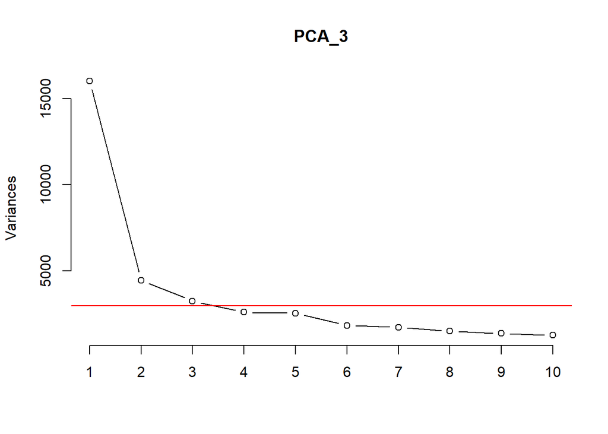

```r
plot(PCA_3, type = "l")
abline(h=3000, col="red")
```

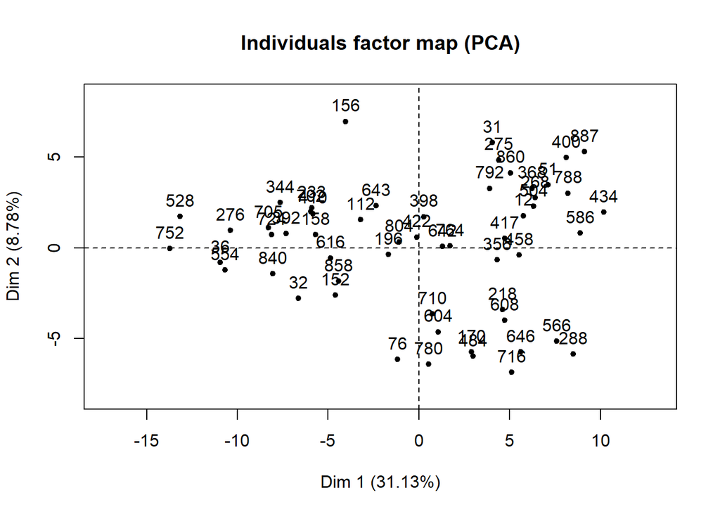

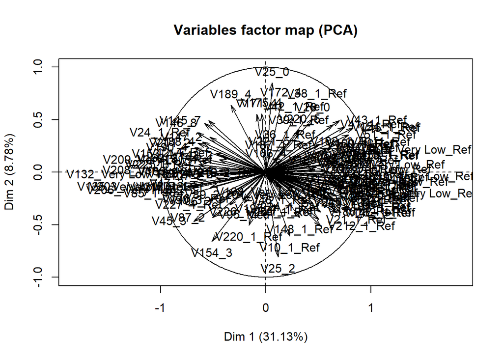

```
## **Results for the Principal Component Analysis (PCA)**
## The analysis was performed on 56 individuals, described by 132 variables
## *The results are available in the following objects:
##
##    name               description
## 1  "$eig"             "eigenvalues"
## 2  "$var"             "results for the variables"
## 3  "$var$coord"       "coord. for the variables"
## 4  "$var$cor"         "correlations variables - dimensions"
## 5  "$var$cos2"        "cos2 for the variables"
## 6  "$var$contrib"     "contributions of the variables"
## 7  "$ind"             "results for the individuals"
## 8  "$ind$coord"       "coord. for the individuals"
## 9  "$ind$cos2"        "cos2 for the individuals"
## 10 "$ind$contrib"     "contributions of the individuals"
## 11 "$call"            "summary statistics"
## 12 "$call$centre"     "mean of the variables"
## 13 "$call$ecart.type" "standard error of the variables"
## 14 "$call$row.w"      "weights for the individuals"
## 15 "$call$col.w"      "weights for the variables"
```

```r
PCA(High_Variance_Variables_Responses)
```

```r
#Loadings have variables as rows
PCA_Loadings3 <- round(PCA_3$rotation [,c(1:5)], 3)
head(PCA_Loadings3)
```

```
##                      PC1    PC2    PC3    PC4    PC5
## V10_1_Ref         -0.026  0.136 -0.011  0.053  0.004
## V100_Very Low_Ref -0.070  0.015  0.090  0.018  0.000
## V102_1_Ref        -0.038 -0.063 -0.035 -0.015  0.001
## V105_4            -0.068  0.035 -0.041 -0.034 -0.043
## V106_2             0.048  0.071 -0.007  0.079  0.061
## V106_4            -0.076 -0.054  0.029 -0.038 -0.076
```

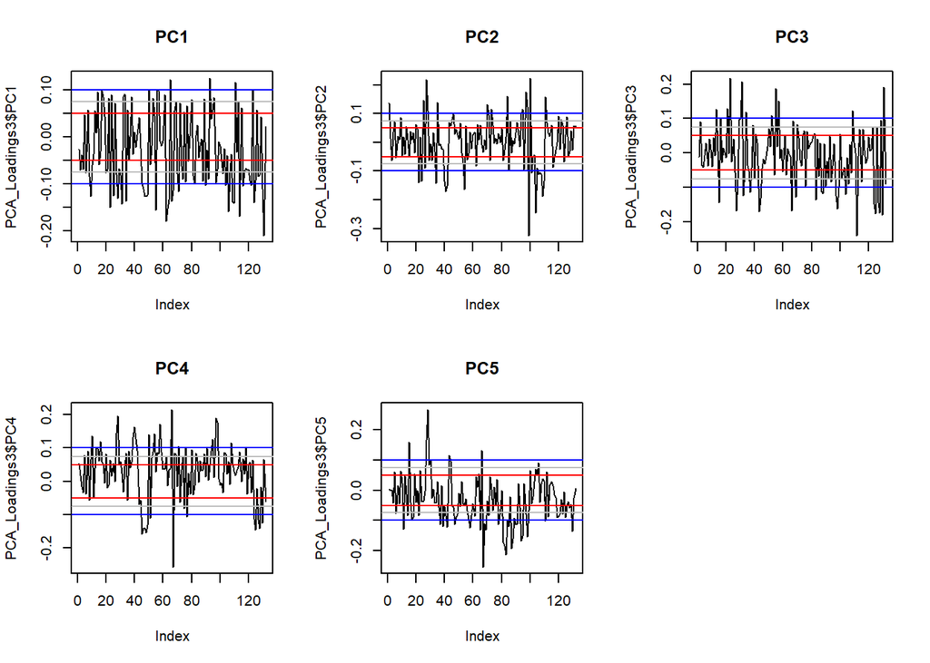

```r
PCA_Loadings3 <- as.data.frame(PCA_Loadings3)

#Plots of Components
#pdf("Loading distribution3.pdf", paper = "USr")
par(mfrow=c(2,3))

plot(PCA_Loadings3$PC1, type = "l", main = "PC1")
abline(h=0.05, col="red")
abline(h=-0.05, col="red")
abline(h=0.075, col="grey")
abline(h=-0.075, col="grey")
abline(h=0.1, col="blue")
abline(h=-0.1, col="blue")

plot(PCA_Loadings3$PC2, type = "l", main = "PC2")
abline(h=0.05, col="red")
abline(h=-0.05, col="red")
abline(h=0.075, col="grey")
abline(h=-0.075, col="grey")
abline(h=0.1, col="blue")
abline(h=-0.1, col="blue")

plot(PCA_Loadings3$PC3, type = "l", main = "PC3")
abline(h=0.05, col="red")
abline(h=-0.05, col="red")
abline(h=0.075, col="grey")
abline(h=-0.075, col="grey")
abline(h=0.1, col="blue")
abline(h=-0.1, col="blue")

plot(PCA_Loadings3$PC4, type = "l", main = "PC4")
abline(h=0.05, col="red")
abline(h=-0.05, col="red")
abline(h=0.075, col="grey")
abline(h=-0.075, col="grey")
abline(h=0.1, col="blue")
abline(h=-0.1, col="blue")

plot(PCA_Loadings3$PC5, type = "l", main = "PC5")
abline(h=0.05, col="red")
abline(h=-0.05, col="red")
abline(h=0.075, col="grey")
abline(h=-0.075, col="grey")
abline(h=0.1, col="blue")
abline(h=-0.1, col="blue")

#dev.off()
```

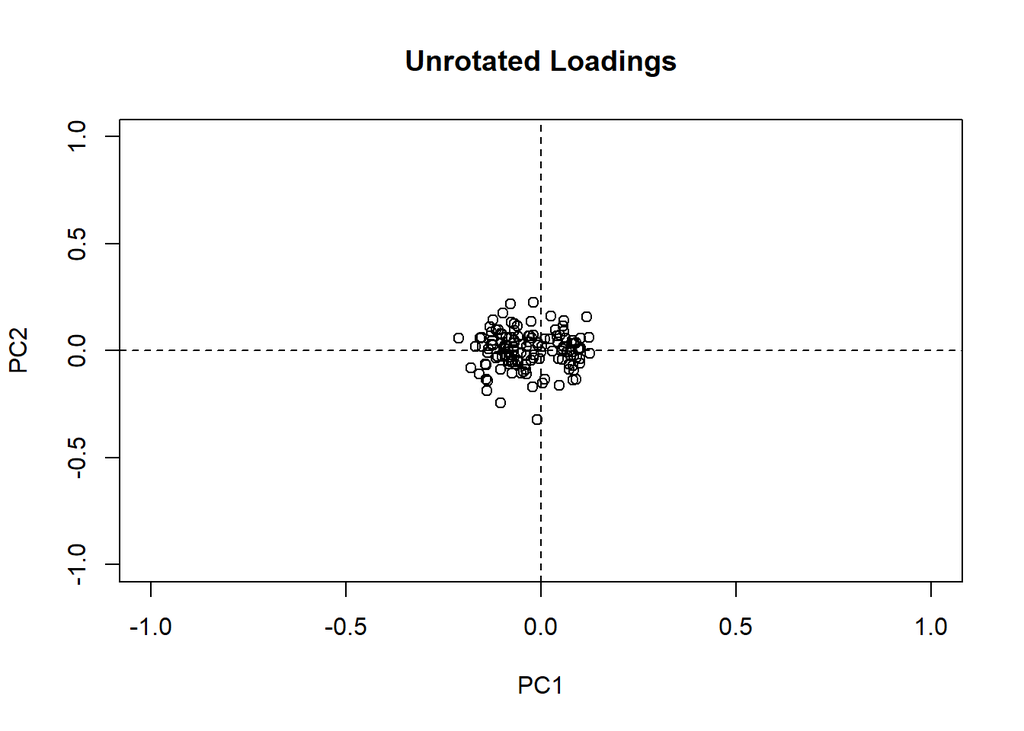

```r
plot(PCA_3$rotation [,c(1:2)], xlim = c(-1, 1), ylim = c(-1, 1), main = "Unrotated Loadings")
abline(v = 0, h = 0, lty = 2)
```

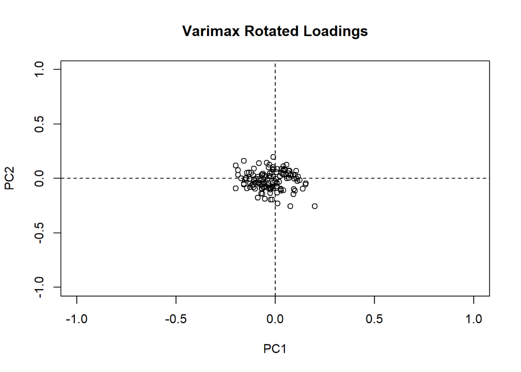

```r
plot(varimax(PCA_3$rotation [,c(1:2)])$loadings, xlim = c(-1, 1), ylim = c(-1, 1), main = "Varimax Rotated Loadings")
abline(v = 0, h = 0, lty = 2)
```

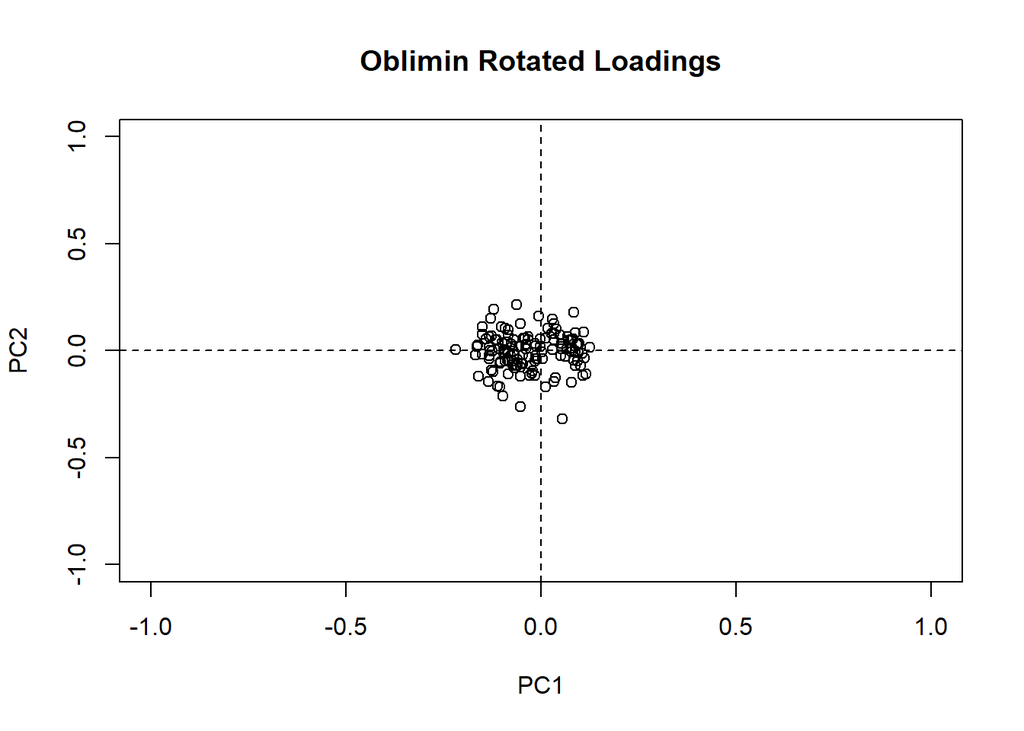

```r
plot(oblimin(PCA_3$rotation [,c(1:2)])$loadings, xlim = c(-1, 1), ylim = c(-1, 1), main = "Oblimin Rotated Loadings")
abline(v = 0, h = 0, lty = 2)
```

```r
PCA_Loadings3[abs(PCA_Loadings3) < 0.1] = NA
PCA_Loadings_Cleaned3 <- PCA_Loadings3[rowSums(is.na(PCA_Loadings3))!= 5, ]


PCA_Scores3 <- PCA_3$x[,c(1:5)]
head(PCA_Scores3)
```

```
##           PC1        PC2         PC3        PC4       PC5
## 12 -109.90357  -33.23126  102.526731 -15.746803  22.41423
## 31  -94.41325 -107.84352 -129.829011  14.926439 -17.29927
## 32  135.44785   59.03318    2.396560  -8.455401 -22.58388
## 36  212.44633   15.91866   43.662901  59.562840 -30.08833
## 51 -136.35733  -61.95802  -92.176452   4.005956 -91.48226
## 76   23.02507  121.22120    1.699508 -36.602197 -29.13844
```

```r
Named_PCA_Analysis_Data3 <- merge(Country_Names, PCA_Scores3, by.y= 0, by.x ="Country.Code", all.y=T)

Renewable_Scores3 <- merge(Renewable_merge, Named_PCA_Analysis_Data3,
                                   by.x="Country.Name", by.y="Country.Title")
Renewable_Scores3 <- Renewable_Scores3[,c(1:7, 12:17)]
Renewable_Scores3 <- na.omit(Renewable_Scores3)
```

### Varaible Reduction:Low Variance Filter - Final Data for Regression

This is the dataframe we will use to explore the relationships between renewable electricity production and cultural values.

```r
Final_Data <- Renewable_Scores3
```

### Varaible Reduction:Low Variance Filter - Linear Regression

```r
fullregression <- lm(log(Final_Data$RE_Generation +1) ~ Final_Data$PC1 +
                       Final_Data$PC2 +Final_Data$PC3)
summary(fullregression)
```

```
##
## Call:
## lm(formula = log(Final_Data$RE_Generation + 1) ~ Final_Data$PC1 +
##     Final_Data$PC2 + Final_Data$PC3)
##
## Residuals:
##      Min       1Q   Median       3Q      Max
## -1.53625 -0.57646 -0.02469  0.74060  1.85586
##
## Coefficients:
##                 Estimate Std. Error t value Pr(>|t|)
## (Intercept)    1.1450426  0.1173343   9.759 4.50e-13 ***
## Final_Data$PC1 0.0052025  0.0009247   5.626 8.78e-07 ***
## Final_Data$PC2 0.0027160  0.0018187   1.493    0.142
## Final_Data$PC3 0.0009114  0.0021958   0.415    0.680
## ---
## Signif. codes:  0 '***' 0.001 '**' 0.01 '*' 0.05 '.' 0.1 ' ' 1
##
## Residual standard error: 0.853 on 49 degrees of freedom
## Multiple R-squared:  0.4137, Adjusted R-squared:  0.3779
## F-statistic: 11.53 on 3 and 49 DF,  p-value: 7.793e-06
```

From these results we can see that only the first PC has a significant relationship with the precentage of renewables at a naitonal level.

### Varaible Reduction:Low Variance Filter - Controlling for GDP

```r
GDP_rawdata <- read.csv("World_Bank_GDP_Data.csv")
GDP_Years <- GDP_rawdata[4,]

#remove first 4 rows to bring column headers to top
GDP_data <- GDP_rawdata[c(5:286),]
colnames(GDP_data) <- GDP_Years

#remove all columns except for country names, and 2015 GDP
GDP_data2015 <-GDP_data[,c(1,60)]
colnames(GDP_data2015)<- c("Country.Title", "2015 GDP")

GDP_data_named<-merge(GDP_data2015, Country_Names, by.x= "Country.Title", by.y = "Country.Title")

GDP_Control <- merge(GDP_data_named, Final_Data, by.x = "Country.Title", by.y= "Country.Name")

Control <- GDP_Control$`2015 GDP`/10^9 #down to 53 countries
```

```r
fullregression <- lm(log(Final_Data$RE_Generation +1) ~ Final_Data$PC1 + Final_Data$PC2 +
                      Final_Data$PC3 + Control)
summary(fullregression)
```

```
##
## Call:
## lm(formula = log(Final_Data$RE_Generation + 1) ~ Final_Data$PC1 +
##     Final_Data$PC2 + Final_Data$PC3 + Control)
##
## Residuals:
##      Min       1Q   Median       3Q      Max
## -1.55362 -0.57173 -0.04114  0.73947  1.85873
##
## Coefficients:
##                 Estimate Std. Error t value Pr(>|t|)
## (Intercept)    1.150e+00  1.271e-01   9.045 8.98e-12 ***
## Final_Data$PC1 5.220e-03  9.879e-04   5.284 3.37e-06 ***
## Final_Data$PC2 2.496e-03  1.831e-03   1.363    0.179
## Final_Data$PC3 7.910e-04  2.211e-03   0.358    0.722
## Control        2.464e-05  4.250e-05   0.580    0.565
## ---
## Signif. codes:  0 '***' 0.001 '**' 0.01 '*' 0.05 '.' 0.1 ' ' 1
##
## Residual standard error: 0.8464 on 46 degrees of freedom
##   (2 observations deleted due to missingness)
## Multiple R-squared:  0.4323, Adjusted R-squared:  0.383
## F-statistic: 8.758 on 4 and 46 DF,  p-value: 2.417e-05
```

Nothing signifincatnly changes when we control for GDP, which is interesting because GDP is considered a moderating (Mediating?) variable in culture studies.

### Varaible Reduction:Low Variance Filter - Other Controls

```r
Renewable_Resources <- read.csv("Renewable_Resources.csv")

Renewable_Resources<- merge(Renewable_Resources, Final_Data, by.x = "Country.Code", by.y = "Country.Code")

Renewable_Gen<- Renewable_Resources$RE_Generation.x
PC1 <- Renewable_Resources$PC1
PC2 <- Renewable_Resources$PC2
PC3 <- Renewable_Resources$PC3
Wind <- Renewable_Resources$Wind
Solar <- as.numeric(Renewable_Resources$Solar)
Policy <- Renewable_Resources$Policy.Target
```

```r
fullregression_resources <- lm(log(Renewable_Gen+1) ~ PC1 + PC2 + PC3 +
                                 Wind + Solar + Policy)
summary(fullregression_resources)
```

```
##
## Call:
## lm(formula = log(Renewable_Gen + 1) ~ PC1 + PC2 + PC3 + Wind +
##     Solar + Policy)
##
## Residuals:
##     Min      1Q  Median      3Q     Max
## -1.4186 -0.5214 -0.0680  0.5582  1.8539
##
## Coefficients:
##               Estimate Std. Error t value Pr(>|t|)
## (Intercept)  1.425e+00  2.192e-01   6.503 1.48e-07 ***
## PC1          3.275e-03  1.327e-03   2.469   0.0184 *
## PC2          2.633e-03  2.410e-03   1.092   0.2820
## PC3          3.102e-03  2.999e-03   1.034   0.3080
## Wind         2.222e-03  2.066e-03   1.075   0.2894
## Solar       -2.232e-05  1.139e-05  -1.961   0.0577 .
## Policy       1.236e-01  5.676e-02   2.178   0.0360 *
## ---
## Signif. codes:  0 '***' 0.001 '**' 0.01 '*' 0.05 '.' 0.1 ' ' 1
##
## Residual standard error: 0.7971 on 36 degrees of freedom
##   (10 observations deleted due to missingness)
## Multiple R-squared:   0.53,  Adjusted R-squared:  0.4517
## F-statistic: 6.767 on 6 and 36 DF,  p-value: 7.329e-05
```

### Varaible Reduction:Low Variance Filter - Linear Regression with Wind Cost Overrun Data

```r
Wind_Cost_Overruns <- read.csv("Wind_Cost_Overrun_Data.csv")

Wind_Cost_Overruns_Final <- merge(Wind_Cost_Overruns, Country_Names, by.x = "Country", by.y = "Country.Title")
Cost_Performance_Wind <- merge(Wind_Cost_Overruns_Final, GDP_Control, by.x ="Country.Code", by.y = "Country.Code.x")
Cost_Performance_Wind_Resources <- merge(Cost_Performance_Wind, Renewable_Resources,
                                         by.x ="Country.Code", by.y = "Country.Code")

fullregression <- lm(Cost_Performance_Wind$X.Cost.Over.Run.2017 ~ Cost_Performance_Wind$PC1 +
                       Cost_Performance_Wind$PC2 +
                       Cost_Performance_Wind$PC3 +
                       Cost_Performance_Wind$Offshore + Cost_Performance_Wind_Resources$Wind)

summary(fullregression)
```

```
##
## Call:
## lm(formula = Cost_Performance_Wind$X.Cost.Over.Run.2017 ~ Cost_Performance_Wind$PC1 +
##     Cost_Performance_Wind$PC2 + Cost_Performance_Wind$PC3 + Cost_Performance_Wind$Offshore +
##     Cost_Performance_Wind_Resources$Wind)
##
## Residuals:
##      Min       1Q   Median       3Q      Max
## -17.4653  -8.0120  -0.3557   8.2149  18.8886
##
## Coefficients:
##                                      Estimate Std. Error t value Pr(>|t|)
## (Intercept)                          10.76801   15.33105   0.702    0.492
## Cost_Performance_Wind$PC1            -0.12385    0.21306  -0.581    0.569
## Cost_Performance_Wind$PC2            -0.14327    0.44150  -0.325    0.750
## Cost_Performance_Wind$PC3             0.41247    1.10494   0.373    0.714
## Cost_Performance_Wind$Offshore       15.62584    9.66344   1.617    0.124
## Cost_Performance_Wind_Resources$Wind -0.00996    0.05638  -0.177    0.862
##
## Residual standard error: 12.22 on 17 degrees of freedom
## Multiple R-squared:  0.3694, Adjusted R-squared:  0.1839
## F-statistic: 1.991 on 5 and 17 DF,  p-value: 0.1317
```

## Varaible Reduction: Non-Parametric Rank Correlations

When hofstede developed his cultural model and dimesnsions he used the Spearman rank correlations to determine which variables to analyze further. For example for the construction of the power distance index, Hofstede choose one question (measured on a likert scale), theorhetically and then looked for other varaibles (likert or porportions) which had strong (over 0.5), signifiant relationships with the orginal questions. He then retained the conceptually related varaibles which had the strongest most signifcant relationship to that orginial question. The final PDI index is based on three vairables.

In this study, we are aiming to avoid using theorhetical elimination of questions; therefore we looked at the Spearman and Kendall correlations between the variables. We are specifically interested in if the variables have a significant relationship with variables outside it’s own question. In the code we calculated the Spearman coefficients. We did not use the pearson correlation corefficients because the variables are not normally distributted.

## Varaible Reduction: Spearman Rank Correlations

```r
Spearman_Correlations <- cor(WVS_Data_Precentages5, method = "spearman")
Spearman_Correlations <- as.data.frame(Spearman_Correlations)
Spearman_Correlations[abs(Spearman_Correlations) < 0.7] = NA

#remove columns/rows which sum to 1 - because that implies that only correlate with themselves at 0.7 or higher
Spearman_Correlations_NoCorr<- Spearman_Correlations[,-(which(colSums(Spearman_Correlations, na.rm=TRUE) == 1.00))]

#the list below is the variables to keep
Correlated_Variables <- names(Spearman_Correlations_NoCorr)

#There are 180 varaibles that do not correlate with anything else. They should be removed from the analysis.
 Spearman_Correlations_0.7Corr<- Spearman_Correlations[Correlated_Variables, Correlated_Variables]

 #However, this still leaves 617 variables - which when looking at some of the correlations, not all of them make sense. This can be attributed to how the Spearman test manages ties in the data. When there is a tie the assigned rank is the average of their values in the separate lists.
 str(Correlated_Variables)
```

```
##  chr [1:620] "V4_1_Ref" "V4_2" "V5_1_Ref" "V5_3" "V5_4" "V6_1_Ref" ...
```

```r
 Eliminate_Spearman <- c("V4_", "V4_","V5_","V5_","V5_","V6_","V6_",
                        "V6_","V7_","V7_","V7_","V7_","V8_","V8_","V8_",
                        "V9_","V9_","V9_","V10_","V10_","V10_","V10_",
                        "V11_","V11_","V19_","V25_","V25_","V25_",
                        "V26_","V26_","V26_","V27_","V27_","V27_",
                        "V28_","V28_","V28_","V29_","V29_","V29_",
                        "V30_","V30_","V30_","V31_","V31_","V31_",
                        "V32_","V32_","V32_2","V33_","V33_","V33_","V34_",
                        "V34_","V34_","V35_","V35_","V35_","V37_","V42_",
                        "V39_","V38_", "V36_","V40_","V41_","V43_","V44_",
                        "V24_","V70_","V70_","V70_","V71_","V71_","V71_",
                        "V71_","V71_","V71_","V72_","V72_","V72_","V72_",
                        "V72_","V73_","V73_","V73_","V73_","V73_",
                        "V75_","V75_","V75_","V75_","V75_","V76_",
                        "V76_","V76_","V76_","V76_","V76_","V77_","V77_",
                        "V77_","V77_","V77_","V78_","V78_","V78_",
                        "V78_","V78_","V78_","V79_","V79_","V79_","V79_",
                        "V79_","V79_","V74_","V74_","V74_","V74_","V74_",
              "V165_","V165_","V166_","V166_","V166_","V167_","V168_","V168_","V168_","V168_",
              "V169_","V169_","V169_","V82_","V45_","V45_","V45_","V46_","V102_","V102_",
              "V102_","V102_","V49_","V49_","V49_","V49_4","V54_","V54_2","V54_3","V54_4",
              "V51_","V51_","V51_","V51_","V52_","V52_2","V52_3","V52_4","V50_1","V50_3",
              "V48_","V47_","V47_","V47_","V53_","V53_","V53_","V53_","V60_","V60_",
              "V61_","V62_","V63_","V64_","V67_","V67_","V67_" ,"V68_","V68_","V69_","V69_","V69_",
              "V84_","V84_","V85_","V85_" ,"V85_","V86_","V86_","V86_","V87_","V87_","V87_","V88_",
              "V88_","V88_","V89_","V89_","V89_","V108_","V108_","V108_","V109_","V109_","V109_",
              "V109_","V110_","V110_","V110_","V110_","V111_","V111_","V111_","V111_","V112_",
              "V112_","V112_","V112_","V113_","V113_","V113_","V113_","V114_","V114_","V114_",
              "V114_","V115_","V115_","V115_","V115_","V116_","V116_","V116_","V116_","V117_",
              "V117_","V117_","V117_","V118_","V118_","V118_","V118_","V119_","V119_","V119_",
              "V120_","V120_","V120_","V120_","V121_","V121_","V121_","V121_","V122_","V122_",
              "V122_","V122_","V123_","V123_","V123_","V123_","V124_","V124_","V124_","V124_",
              "V126_","V126_","V126_","V127_","V127_","V128_","V129_","V129_","V129_","V130_",
              "V130_","V142_","V142_","V142_","V217_","V217_","V217_","V218_","V218_","V219_",
              "V219_","V219_","V220_","V220_","V221_","V221_","V221_","V222_","V222_","V222_",
              "V222_","V222_","V223_","V223_","V223_","V223_","V223_","V225_","V225_","V226_",
              "V226_","V226_","V227_","V227_","V227_","V143_","V143_","V143_","V145_","V145_",
              "V145_","V145_","V146_","V146_","V146_","V147_","V147_","V147_","V148_","V149_",
              "V150_","V150_","V150_","V151_","V151_","V151_","V153_","V153_","V153_","V153_",
              "V154_","V154_","V154_","V155_","V155_","V156_","V156_","V156_","V211_","V211_",
              "V211_","V211_","V103_","V103_","V103_","V104_","V104_","V104_","V106_","V106_",
              "V106_","V106_","V107_","V107_","V107_","V107_","V212_","V212_","V212_","V212_",
              "V213_","V213_","V213_","V213_","V214_","V214_","V214_","V214_","V216_","V216_",
              "V216_","V243_","V244_","V170_","V170_","V171_","V171_","V171_","V171_","V172_",
              "V172_","V172_","V173_","V173_","V173_","V173_","V174_","V174_","V174_","V174_",
              "V175_","V175_","V175_","V175_","V176_","V177_","V179_","V180_","V181_","V181_",
              "V181_","V181_","V182_","V182_","V182_","V182_","V183_","V183_","V183_","V183_",
              "V184_","V184_","V184_","V184_","V185_","V185_","V185_","V185_","V186_","V186_",
              "V188_","V188_","V188_","V188_","V189_","V189_","V189_","V189_","V190_","V190_",
              "V190_","V190_","V191_","V191_","V191_","V191_","V23_","V23_","V23_","V23_",
              "V23_","V56_","V56_","V55_","V55_","V55_","V55_","V55_","V157_","V157_",
              "V158_","V158_","V158","V159_","V159_","V159_","V159_","V160_","V164_",
              "V164_","V59_","V59_","V59_","V59_ ","V96_","V96_","V96_","V96_","V97_",
              "V97_","V97_","V98_","V98_","V98_","V98_","V99_","V99_","V99_","V100_",
              "V100_","V100_","V100_","V101_","V101_","V101_","V101_","V131_","V131_","V131_",
              "V131_","V132_","V132_","V132_","V132_","V132_","V134_","V134_","V134_","V134_",
              "V134_","V135_","V135_","V135_","V135_","V135_","V136_","V136_","V136_","V136_",
              "V136_","V137_","V137_","V137_","V137_","V138_","V138_","V138_","V141_","V141_",
              "V141_","V141_","V192_","V192_","V192_","V194_","V194_","V194_","V194_","V194_",
              "V197_","V197_","V197_",
              "V197_","V197_","V198_","V198_","V198_","V198_","V198_","V200_","V200_","V200_",
              "V200_","V200_","V209_","V209_","V209_","V209_","V209_","V210_","V210_","V210_",
              "V210_","V210_","V199_","V199_","V199_","V199_","V199_","V201_","V201_","V201_",
              "V201_","V201_","V202_","V202_","V202_","V202_","V202_","V203_","V203_","V203_",
              "V203_","V203_","V204_","V204_","V204_","V204_","V205_","V205_","V205_","V205_",
              "V207_","V207_","V207_","V207_","V207_","V206_","V206_","V206_","V208_","V208_",
              "V208_","V208_","V208_",
              "V195_","V195_","V195_","V195_","V196_","V196_","V196_","V196_",
              "V161_","V161_","V161_","V162_","V162_","V162_","V163_",
              "V163_","V163_")
Keep <- c()
i=1
for (aRow in Correlated_Variables[c(1:617)]){
  DF <- abs(Spearman_Correlations_0.7Corr[ , -grep(Eliminate_Spearman[i], colnames(Spearman_Correlations_0.7Corr))])
  sum <- sum((DF[aRow,]), na.rm=T)
  if(sum>0){Keep <- cbind(Keep, aRow)} #if sum of row is greater than 0, keep the row.
  #if(is.na(sum==T)){next}
  i=i+1
}
Keep <- c(Keep[1,])
str(Keep)
```

```
##  Named chr [1:581] "V4_1_Ref" "V4_2" "V5_3" "V5_4" "V6_3" "V6_4" ...
##  - attr(*, "names")= chr [1:581] "aRow" "aRow" "aRow" "aRow" ...
```